# Your Biennial Visual Tech Round-up

Myfanwy Johnston

These slides have been edited from their original version. They have been formatted for better understanding by people not present at the conference in March.

### So here's what we're going to do:

1) Making better/more effective graphs

```
  - Enormous topic
  - I'll show you an examples of a graph type you may not have seen before
```

2) **Brief** introduction to Git/GitHub

3) **Brief** introduction to rmarkdown

4) An actual workflow, from start to finish

### We'll start with the graphs you need to stop making, right now.

No more pie charts.  
(…unless it's this one)

[figure not shown]

Ironically, pie charts are bad at communicating the basics (scale, order, trends)

Use a bar chart instead, or for trends across time, use a (single) stacked bar chart.

### No more grouped bar charts

It is difficult to do meaningful visual comparison with grouped bar charts.

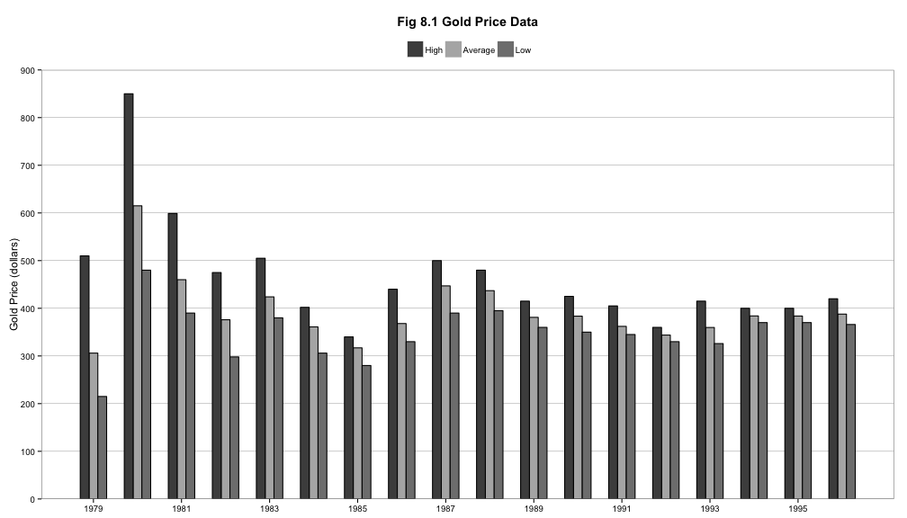

### Do This Instead

For these data, this graph better allows the audience to read the trend for themselves.

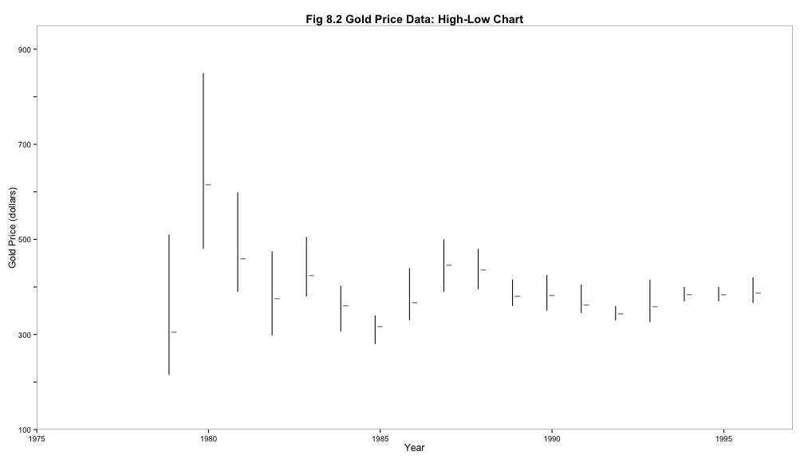

### Violin Jitter Plots

Consider for data that has many observations distributed assymmetrically.

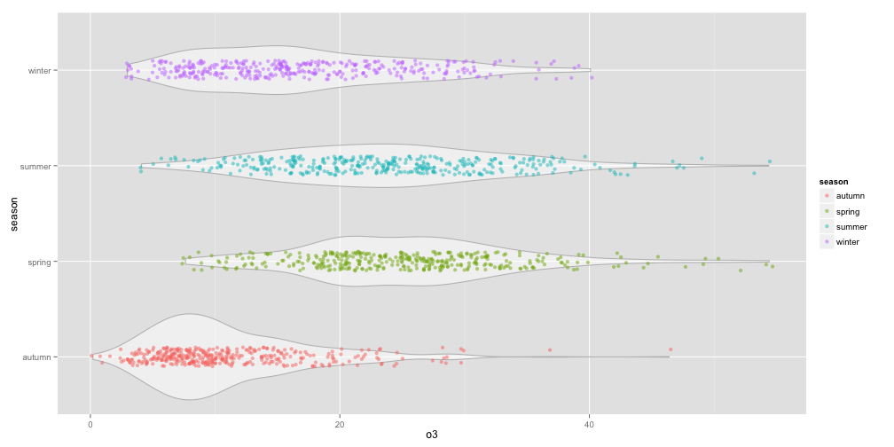

Graph tutorial credit: Zev Ross

### Good data visualization in the wild

[New York Times](http://www.nytimes.com/imagepages/2007/12/10/science/20071211_WHALE_GRAPHIC.html)

[FiveThirtyEight](http://fivethirtyeight.com/datalab/theres-a-gap-between-what-the-public-thinks-and-what-scientists-know/)

ESPN

### A Windy road

[figure not shown]

There are some seriously good arguments for an R-based workflow.

It's not perfect yet.

### GitHub

**77%** of you said you don't know what GitHub is.

So let's ctrl-click and [go to GitHub](http://www.github.com/)

If you haven't yet created an account, go ahead and do that now.

For more information, check out GitHub's extremely well-organized and written [help documentation](https://help.github.com/)

### So GitHub is actually

A user-friendly wrapper* for Git

*and so much more than that

### What is Git?

- An open source version control project started by Linux creator Linus Torvalds.
- Git manages and stores revisions of projects.
- Mostly used for code, but can be used to manage any other type of file.
  - Like a filing system for every draft of a document.
- If you want to make a change to a project, you copy the whole project repository to your own system, make your changes on that local copy, then you “check in” the changes to the central server.
  - Command line
- Okay so what is GitHub again?

### GitHub

- GitHub is a Git repository hosting service
  - Paraphrasing Jennifer Bryan (UBC), GitHub represents “an end to file salad”
- Git = command line, GitHub = web-based GUI
- Provides access control and several collaboration features.
  - Fork, Pull Request, Merge

[figure not shown]

### What is R Markdown?

- This slideshow is an R Markdown presentation (via .Rpres).

…and begin Carson Sievert Slides

Markdown syntax

```
Header 1
================
Header 2
----------------
### Header 3

This is regular text.

> This is a blockquote.
>
> This is the second paragraph in the blockquote.
>
> ## This is an H2 in a blockquote
```

Resulting HTML

```
<h1>Header 1</h1>
<h2>Header 2</h2>
<h3>Header 3</h3>

<p>This is regular text.</p>

<blockquote>
<p>This is a blockquote.</p>

<p>This is the second paragraph in the blockquote.</p>

<h2>This is an H2 in a blockquote</h2>
</blockquote>
```

### Header 1

## Header 2

### Header 3

This is regular text.

> This is a blockquote.

> This is the second paragraph in the blockquote.

## This is an H2 in a blockquote

Markdown syntax

```
Here we have an unordered list.

* Item 1
* Item 2
  * Item 2a
  * Item 2b

Here we have an ordered list

1. Item 1
2. Item 2
  * Item 2a
  * Item 2b
```

Resulting HTML

```
<p>Here we have an unordered list.</p>
<ul>
<li>Item 1</li>
<li>Item 2
<ul>
<li>Item 2a</li>
<li>Item 2b</li>
</ul></li>
</ul>
<p>Here we have an ordered list</p>
<ol>
<li>Item 1</li>
<li>Item 2
<ul>
<li>Item 2a</li>
<li>Item 2b</li>
</ul></li>
</ol>
```

Here we have an unordered list.

- Item 1
- Item 2
  - Item 2a
  - Item 2b

Here we have an ordered list

1. Item 1
2. Item 2
   - Item 2a
   - Item 2b

Markdown syntax

````
What if we want to *italicize* or **bold**?

* In a list, I may want to _italicize_ or __bold__ this way.

I can also include inline `code` or

```
blocks of code
```
Or even a [link](http://google.com)
````

Resulting HTML

```
<p>What if we want to <em>italicize</em> or <strong>bold</strong>?</p>
<ul>
<li>In a list, I may want to <em>italicize</em> or <strong>bold</strong> this way.</li>
</ul>
<p>I can also include inline <code>code</code> or </p>
<pre><code>blocks of code</code></pre>
<p>Or even a <a href="http://google.com">link</a> </p>
```

What if we want to *italicize* or **bold**?

- In a list, I may want to *italicize* or **bold** this way.

I can also include inline `code` or

```
blocks of code
```

Or even a [link](http://google.com)

### Takeaway message: RStudio + R Markdown + GitHub = your friend

[figure not shown]

### Project Workflow:

Tag life study (~1/64 of my dissertation)

1. Create an .rproj on local directory using “Create Git Repository” option.
2. Load data, tidy data, analyze data, and create some figures.
3. Copy and paste r script into several .rmd files (PDF/LaTeX, HTML, Presentation)
4. Create a ShinyApp, if you like
5. Push to GitHub using Git Software or the website itself (“Publish Repository”)
6. Clone to desktop again for revising.

At this point in the original presentation, I opened RStudio and worked through the Tag Life Study example. A very similar .r script for that example can be found [here](http://github.com/Myfanwy/ggplot2Intro/blob/master/demo.r).

In the live presentation, I demonstrated the the process of creating a repository, linking it to a directory on my hard drive, running the r script, knitting and saving a PDF, and then committing and syncing the changes with the [GitHub client](https://mac.github.com/).

If you're accessing these slides later, you'll have to go through that process yourself, or check out [another good online tutorial](https://guides.github.com/activities/hello-world/).

### You promised us interactive visualizations

These can be achieved with:

- Shiny Apps
- ggvis (similar to ggplot2, but designed with interactive graphs in mind)
- D3

### ShinyApps

Composed of two code files.  
1: A User interface (ui.r) that defines the 'look' of the app online.

```r
library(shiny)
shinyUI(fluidPage(
  # Application title
  titlePanel("Hello Haleys!"),
  sidebarLayout(
    sidebarPanel(
      sliderInput("x", "Minimum number of girls with that name", min=5, max = 80000, value = 50,
                  step=500, round = TRUE, width = '100%'),
      actionButton("goButton", label = "Nope, hate 'em, try again") ),
    mainPanel(
      tableOutput("y")
    ))
))
```

### ShinyApps

2.) A server file (server.r) that tells the server how to actually generate the plots.

```r
library(shiny)
library(babynames)
shinyServer(function(input, output) {
  output$y <- renderTable({
    input$goButton
    dist <- isolate(babynames %>%
                      filter(sex=='F', n > input$x) %>%
                      sample_n(., 5) %>%
                      select(year, name, n) %>%
                      arrange(desc(n))
  )
    dist$year <- as.integer(dist$year)
    print(dist)
  })
})
```

### These two files combine to run a

- [Shiny App on the internet](https://myfanwy.shinyapps.io/NameThatHaley/) (or in a markdown file)

[figure not shown]

### Summing Up

- When you work in R, work in Rmarkdown
- When you make graphics, go straight to ggplot2. Do not pass base graphics, do not pass qplot. Proceed directly to ggplot2.
- GitHub makes sense for data sanity, not just for publishing data on the web.
- For interactive visualization, ShinyApps are one standalone way to go. Otherwise, ggvis + GitHub Pages is a great option.

[figure not shown]

### Of course.

This repo on [GitHub](https://github.com/Myfanwy/VisualTechRoundup2015) - all materials, including slides in PDF  
Also has links to more teaching resources on all these things

### Hey Thanks! Especially:

Noam Ross / Davis R-Users Group  
Dr. Jennifer Bryan (thanks for the Fields talk inspiration)  
Carson Sievert, whose RMarkdown slides I forked from GitHub (see? See how useful?)

[figure not shown]